# Homework SDS

Andrea De Vincenzo, Domenico Azzarito and Michele Pezza

2025-01-05

# Part 1

## 1. Bayes classification rule $\eta^{*}(x)$

$(Y,X)$ are random variables with $Y \in \{0,1\}$ and $X \in \mathbb{R}$. Suppose that

$$(X \mid Y = 0) \sim \text{Unif}(-3, 1) \quad \text{and} \quad (X \mid Y
= 1) \sim \text{Unif}(-1, 3)$$

Further suppose that $\mathbb{P}(Y = 0) = \mathbb{P}(Y = 1) = \frac{1}{2}$.

The regression function is defined as follows:
$$r(x) = \mathbb{E}(Y \mid X = x) = \mathbb{P}(Y=1 \mid X = x) =
\dfrac{\pi_1f_1(x)}{\pi_1f_1(x) + (1-\pi_1)f_0(x)}$$

where $\pi_1 = \mathbb{P}(Y = 1), f_1(x) = f(x \mid Y = 1) \text{ and } f_0(x) = f(x \mid Y = 0)$.

The Bayes classification rule $\eta^{*}(x)$ is defined as:

$$\eta^*(x) =
\begin{cases}
1 & \text{if } \mathbb{P}(Y = 1 | X = x) > \mathbb{P}(Y = 0 | X =
x) \\
0 & \text{otherwise}
\end{cases} = \begin{cases}
1 & \text{if } \pi_1f_1(x) > (1-\pi_1)f_0(x) \\
0 & \text{otherwise}
\end{cases}$$

Since we have $\pi_1 = \pi_0 = \frac{1}{2}$:
$$\eta^*(x) =
\begin{cases}
1 & \text{if } f_1(x) > f_0(x) \\
0 & \text{otherwise}
\end{cases}$$

In our setup:
$$f_1(x) =
\begin{cases}
\frac{1}{4} & \text{if } -1 \leq x \leq 3 \\
0 & \text{otherwise}
\end{cases}
\quad \text{and} \quad f_0(x) =
\begin{cases}
\frac{1}{4} & \text{if } -3 \leq x \leq 1 \\
0 & \text{otherwise}
\end{cases}$$

- $x < -3$:
  $$f_1(x) = 0, \; f_0(x) = 0 \Rightarrow f_1(x) \not> f_0(x) \Rightarrow
  \eta^{*}(x) = 0$$
- $-3 \leq x < -1$:
  $$f_1(x) = 0, \; f_0(x) = \frac{1}{4} \Rightarrow f_1(x) \not> f_0(x)
  \Rightarrow \eta^{*}(x) = 0$$
- $-1 \leq x \leq 1$:
  $$f_1(x) = \frac{1}{4}, \; f_0(x) = \frac{1}{4} \Rightarrow f_1(x)
  \not> f_0(x) \Rightarrow \eta^{*}(x) = 0$$
- $1 < x \leq 3$:
  $$f_1(x) = \frac{1}{4}, \; f_0(x) = 0 \Rightarrow f_1(x) > f_0(x)
  \Rightarrow \eta^{*}(x) = 1$$
- $x > 3$:
  $$f_1(x) = 0, \; f_0(x) = 0 \Rightarrow f_1(x) \not> f_0(x) \Rightarrow
  \eta^{*}(x) = 0$$

Hence, here the Bayes classification rule $\eta^{*}(x)$ is:

$$\eta^*(x) =
\begin{cases}
1 & \text{if} \quad 1 < x \leq 3 \\
0 & \text{otherwise}
\end{cases}$$

## 2.

Now, we generate a dataset of size $n = 1000$ from the joint data model $p(y, x) = p(x | y) \cdot p(y)$ described earlier. The data will include samples drawn from the specified uniform distributions for $X$ conditioned on $Y$. We will then use this dataset to visualize the decision boundaries of the Bayes classifier, evaluate its performance, and compare it with a logistic regression classifier. This process allows us to assess the effectiveness of each method in terms of classification accuracy.

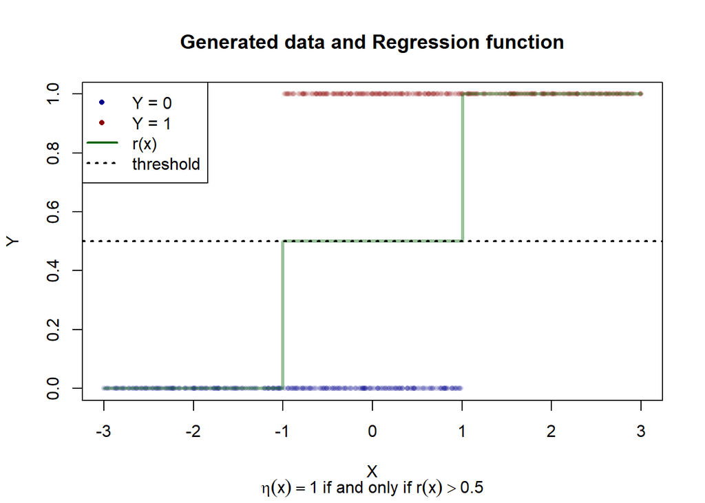

```r
set.seed(54) # We begin with setting the seed for reproducibility
n = 1000 # Sample size
p = 0.5 # Parameter for Bernoulli distribution
# Define the distribution
simulate = function(n){
  y = rbinom(n, 1, p) # We generate Y ~ Ber(p = 0.5)
  x = ifelse(y == 0, runif(n, -3, 1), runif(n, -1, 3))  # X conditional on Y
  data.frame(x = x, y = y)
}
# We simulate one dataset
data <- simulate(n)

# We define the regression function
reg_fun = function(x){
  dunif(x,-1,3) / (dunif(x,-1,3) + dunif(x,-3,1))
}

# Plot the data
plot(data$x, data$y,
     col = ifelse(data$y == 1, adjustcolor("darkred", alpha.f = 0.1),
                                  adjustcolor("darkblue", alpha.f = 0.1)),
     pch = 16, cex = 0.7, xlab = "X", ylab = "Y",
     main = "Generated data and Regression function",
     sub = expression(eta(x) == 1 ~ "if and only if" ~ r(x) > 0.5))

# Plot the Regression Function r(x)
x_seq <- seq(-3, 3, length.out = 1000)
r_values <- reg_fun(x_seq)

lines(x_seq, r_values, type = 's',
      col = adjustcolor("darkgreen", alpha.f = 0.4), # Adjust transparency with alpha.f
      lwd = 3) # Line width


# Add the regression function threshold
abline(h = 0.5, lty = 3, lwd =2)

# Add Legend
legend("topleft", legend = c("Y = 0", "Y = 1", "r(x)",'threshold'),
       col = c('darkblue','darkred','darkgreen','black'), lty = c(0, 0, 1,3),
       pch = c(16, 16, NA,NA), pt.cex = c(0.7, 0.7, NA,NA), lwd = c(NA, NA, 2,2))
```

```r
# Define Bayes Classifier
bayes_classifier <- function(x) {
  ifelse(x > 1 & x <= 3, 1, 0)
}

# We evaluate its performance

# Predict using the Bayes classifier
data$y_pred <- bayes_classifier(data$x)

accuracy <- mean(data$y == data$y_pred)
cat("Accuracy of Bayes Classifier:", accuracy, "\n")
```

```
## Accuracy of Bayes Classifier: 0.733
```